# 2.Quickly_Exploring_Data

LiuYueR

2023-03-09

# Chapter 2 Quickly Exploring Data

虽然我在本书的大部分图形中都使用了 `ggplot2` 包，但它并不是绘制数据的唯一方法。为了快速探索数据，有时使用`base R` 中的绘图函数很有用。这些函数默认随 `R` 一起安装，不需要安装任何额外的包。它们的输入速度很快，在简单情况下使用起来很直接，而且运行速度非常快。

但是，如果您想做的不仅仅是非常简单的绘图，切换到 `ggplot2` 通常会更好。这部分是因为 `ggplot2` 提供了一个统一的界面和一组选项，而不是基础图形中所需的修饰符和特殊情况的抓包。一旦了解了 `ggplot2` 的工作原理，就可以将这些知识用于从散点图和直方图到小提琴图和地图的所有内容。

本节中的每个配方都展示了如何使用基本图形制作图形。每个食谱还展示了如何使用 `ggplot2` 中的函数制作类似的图形`ggplot()`。本书前一版也给出了使用`qplot()` `ggplot2`包中函数的例子，现在推荐直接使用`ggplot()`。

如果您已经知道如何使用 `R` 的基础图形，将这些示例放在一起将有助于您在想要制作更复杂的图形时过渡到使用 `ggplot2`。

## 2.1 Creating a Scatter Plot

### 2.1.1 Problem

创建散点图

### 2.1.2 Solution

要绘制散点图，可以使用`Base R`中的`plot()`，并且传递一个`x`的向量，然后传入一个`y`的向量：

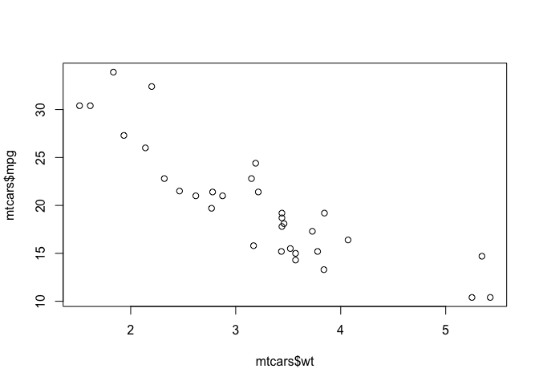

```r
plot(mtcars$wt, mtcars$mpg)
```

`mtcars$wt`返回的是`mtcars`数据框的`wt`的列， `mtcars$mpg`返回的是`mpg`这一列。

使用`ggplot2`绘制图形的时候，你可以使用`ggplot2`函数获取到一个相似的结果

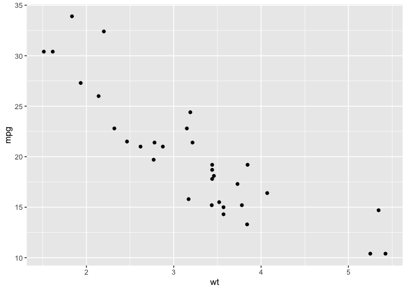

```r
library(ggplot2)

ggplot(mtcars, aes(x = wt, y = mpg)) +
  geom_point()
```

第一部分，`ggplot2` 告诉它创建一个`plot`对象，第二部分`geom_point()`告诉它向`plot`添加一层散点。

使用`ggplot()`的通常方法是向他传递一个数据框(`mtcars`)，然后告诉它使用哪些列作为`x`和`y`的值。

如果你想传递给它`x`和`y`值两个向量，那么你可以使用`data = NULL`，然后传递给它向量。

请记住，`ggplot2`的设计目的是将数据框作为数据源，而不是单独的向量，以这种方式使用它只允许您使用其有限的部分功能。

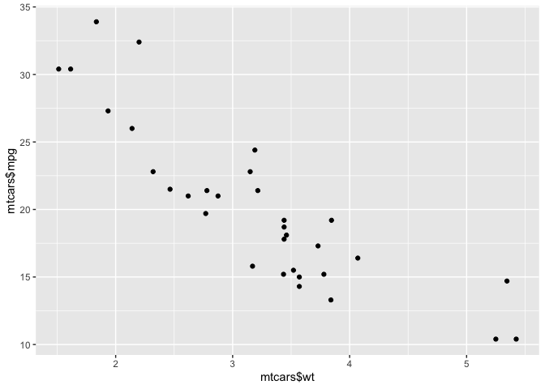

```r
ggplot(data = NULL, aes(x = mtcars$wt, y = mtcars$mpg)) +
  geom_point()
```

通常你会看到`ggplot2()`命令分布在多行中，所以你可能会看到上面的代码可能会写成这样：

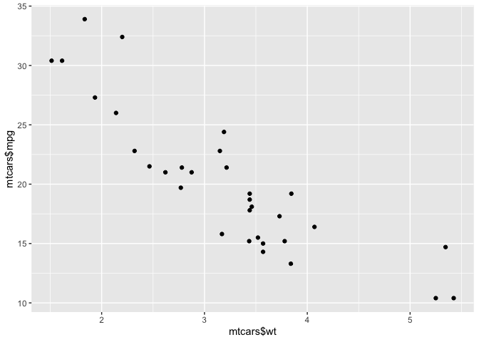

```r
ggplot(data = NULL,
       aes(x = mtcars$wt,
           y = mtcars$mpg)) +
  geom_point()
```

在`Chapter 5`中你会看到关于散点图的更多的细节。

## 2.2 Creating a Line Graph

### 2.2.1 Problem

创建折线图

### 2.2.2 Solution

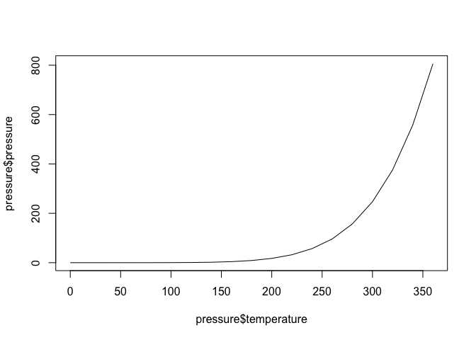

```r
plot(pressure$temperature, pressure$pressure, type = "l")
```

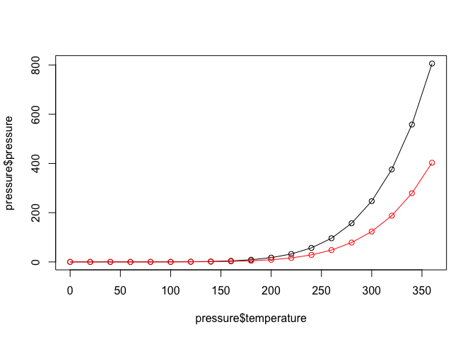

```r
plot(pressure$temperature, pressure$pressure, type = "l")
points(pressure$temperature, pressure$pressure)

lines(pressure$temperature, pressure$pressure/2, col="red")
points(pressure$temperature, pressure$pressure/2, col="red")
```

使用`ggplot2`，你可以使用`geom_line()`获得相似的结果

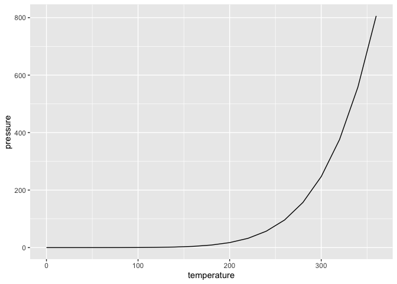

```r
library(ggplot2)

ggplot(pressure, aes(x = temperature, y = pressure)) +
  geom_line()
```

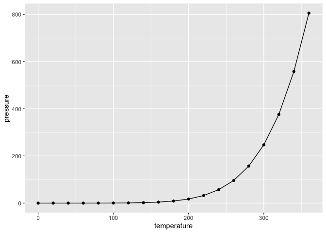

```r
ggplot(pressure, aes(x = temperature, y = pressure)) +
  geom_line() +
  geom_point()
```

> Note ggplot() 通常将命令行拆分为多行，每行以一个`+`结尾，以便让`R`知道该命令行将在下一行继续。

你将在第四章学习更多的`line graph`的细节。

## 2.3 Creating a Bar Graph

### 2.3.1 Problem

绘制一个柱形图

### 2.3.2 Solution

要绘制柱形图，可以在`Base R`中使用`barplot()`，并且向其传递每个柱形图的高度的值，以及每个柱形图的标签的向量。

如果`vector`中元素有名称，则这些名称将会自动用做标签：

```r
BOD
```

```
##   Time demand
## 1    1    8.3
## 2    2   10.3
## 3    3   19.0
## 4    4   16.0
## 5    5   15.6
## 6    7   19.8
```

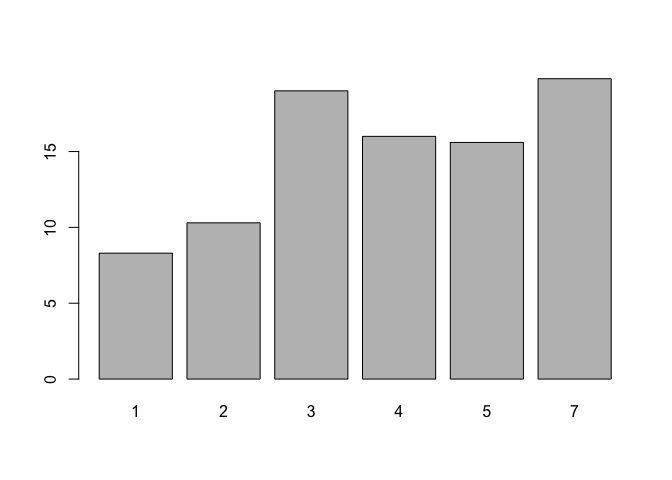

```r
barplot(BOD$demand, names.arg = BOD$Time)
```

有时候，`bar graph`指的是一个图，其中条形图代表每个类别的个数。 这类似于直方图，但是`x`轴是离散的，而不是连续的。 要生成一个`vector`中每个唯一值的计数，使用`table()`函数：

```r
table(mtcars$cyl)
```

```
##
##  4  6  8
## 11  7 14
```

然后传入`barplot()`去生成图：

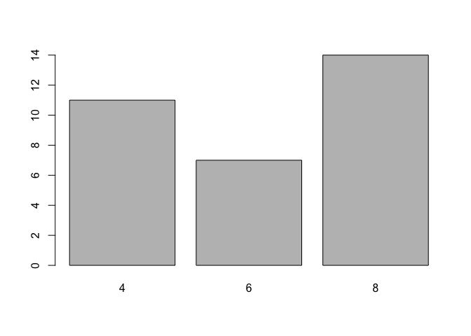

```r
barplot(table(mtcars$cyl))
```

使用`ggplot2`，可以使用`geom_col()`得到类似的结果。要绘制条形图，可以使用`geom_col()`。 注意，当x变量是连续性或者离散型的结果时，输出的图片是有区别的：

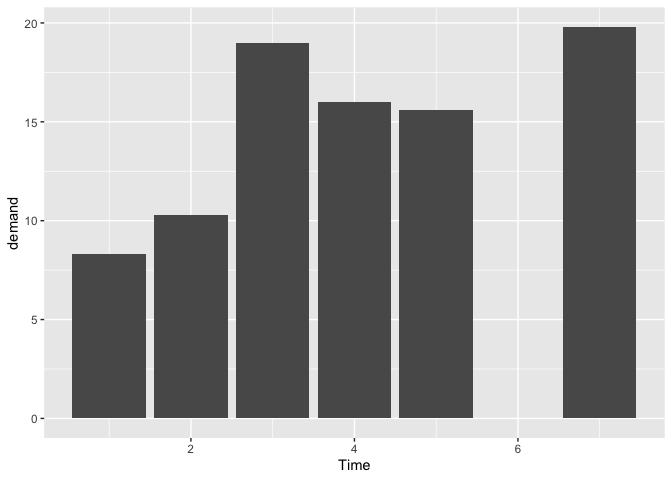

```r
library(ggplot2)

ggplot(BOD, aes(x = Time, y = demand)) +
  geom_col()
```

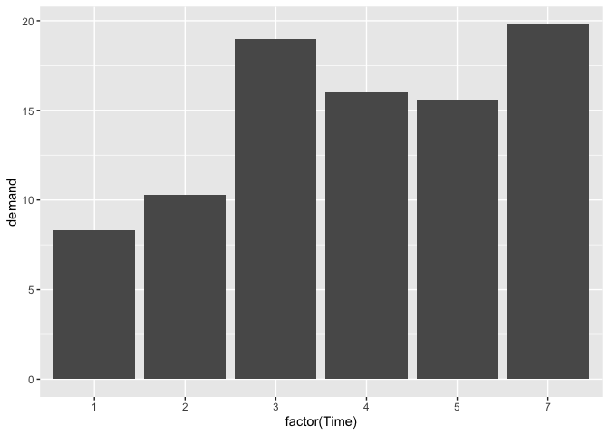

```r
ggplot(BOD, aes(x = factor(Time), y = demand)) +
  geom_col()
```

通过使用`geom_bar()`而不是`geom_col()`，也可以绘制柱形图。再一次，连续性`x`轴和离散型`x`轴的区别。 对于某些类型的数据，使用`factor()`函数将连续的`x`变量转化为离散的`x`变量可能更加有意义。

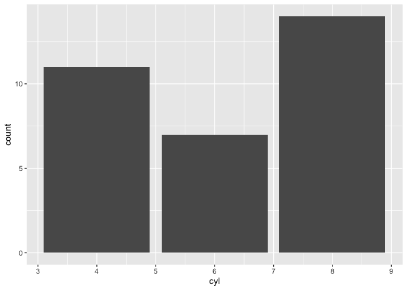

```r
ggplot(data = mtcars, aes(x = cyl)) +
  geom_bar()
```

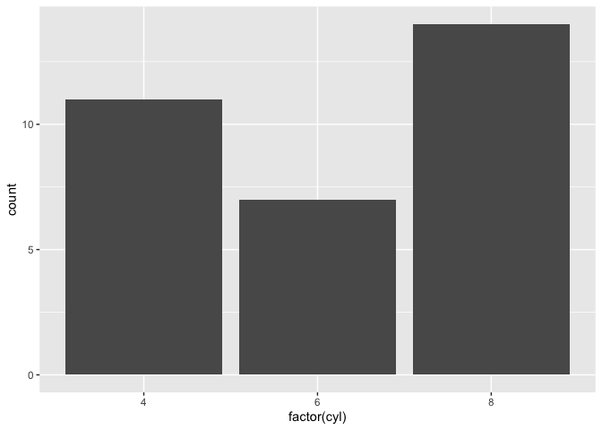

```r
ggplot(data = mtcars, aes(x = factor(cyl))) +
  geom_bar()
```

> Note 在之前版本的`ggplot2`中，创建柱形图的推荐的方法是使用`geom_bar(stat = "identity")`。 从`ggplot2 2.2.0`开始，有一个`geom_col()`函数可以做同样的事情。

在`Chapter 3`中可以看到`bar graphs`的更多的细节。

## 2.4 Creating a Histogram

### 2.4.1 Problem

您希望使用直方图查看一个一维数据的分布情况。

### Solution

绘制一个直方图，使用`hist()`并且向函数里面传递一个数值型的向量。

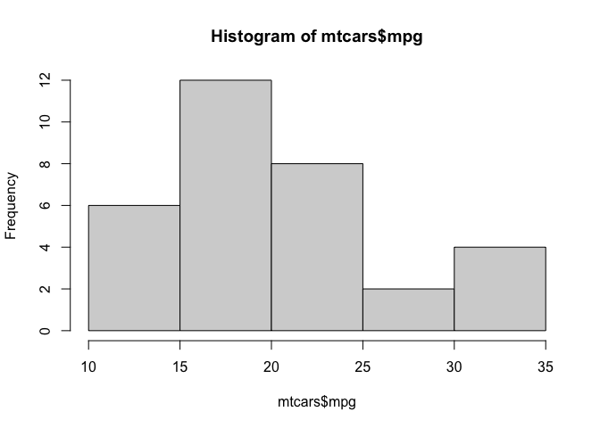

```r
hist(mtcars$mpg)
```

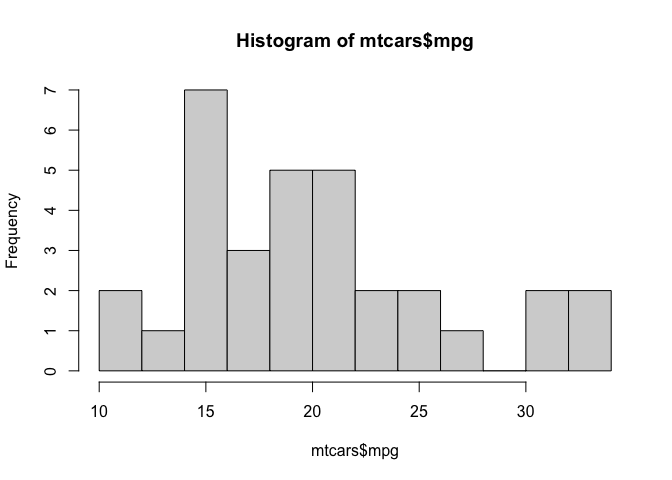

```r
hist(x = mtcars$mpg, breaks = 10)
```

使用`ggplot2`，你可以使用`geom_histogram()`获取一个相似的结果：

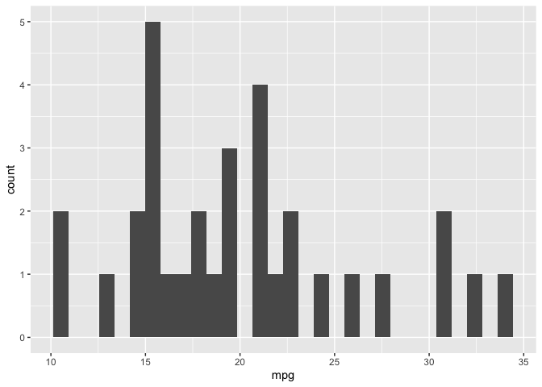

```r
library(ggplot2)

ggplot(mtcars, aes(x = mpg)) +
  geom_histogram()
```

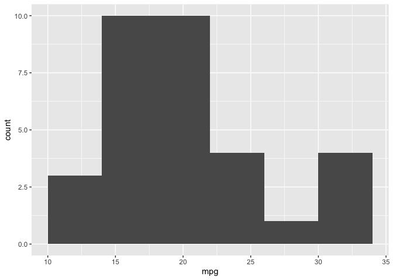

```r
ggplot(mtcars, aes(x = mpg)) +
  geom_histogram(binwidth = 4)
```

当创建一个柱形图而不指定`bin`的宽度时，`ggplot()`会输出一条消息，告诉您默认为`bins`为`30`，并且选择了一个更好的`bin width`。 这是因为使用不同的`bin width`来探索数据是很重要的；默认值为`30`可能会显示有关数据的有用的信息，当然也可能不会。

有关于创建直方图的更多的细节，可以参阅`Recipe 6.1`和`Recipe 6.2`。

## 2.5 Creating a Box Plot

### 2.5.1 Problem

你想创建一个箱线图去比较不同的分布。

### 2.5.2 Solution

要绘制一个箱形图，使用`plot()`并且传递一个`x`轴的因子数据和一个`y`轴的数值向量。当`x`是一个因子（而不是一个数值向量时）， 它会自动创建一个箱形图。

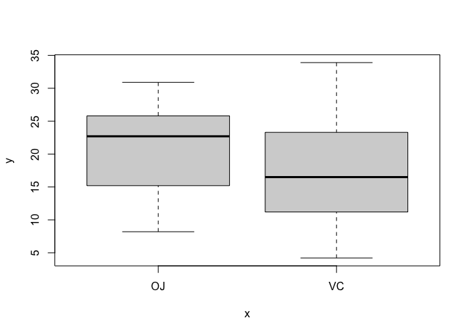

```r
plot(ToothGrowth$supp, ToothGrowth$len)
```

如果两个向量在同一个数据框中，还可以使用公式语法的`boxplot()`。使用这种语法，你可以在`x`轴上组合两个变量。

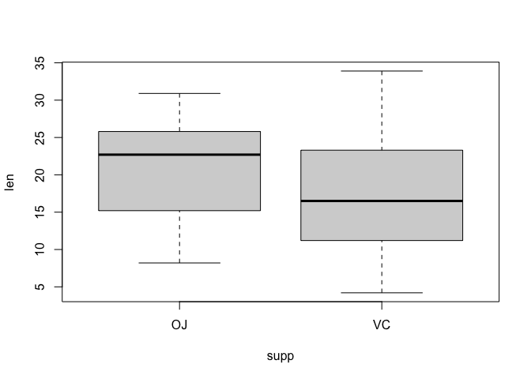

```r
# Formula syntax
boxplot(len ~ supp, data = ToothGrowth)
```

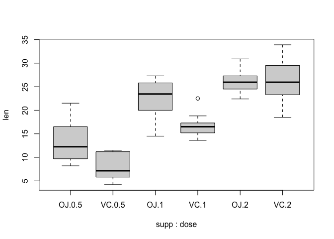

```r
# Put interaction of two variables on x-axis
boxplot(len ~ supp + dose, data = ToothGrowth)
```

使用`ggplot2`包中的`geom_boxplot()`，你可以获得类似的结果：

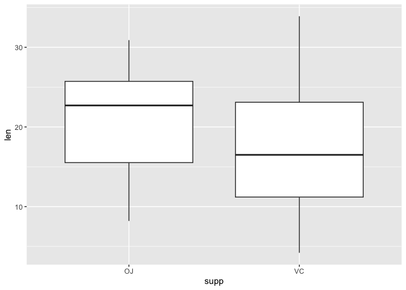

```r
library(ggplot2)

ggplot(ToothGrowth, aes(x = supp, y = len)) +
  geom_boxplot()
```

通过将变量于`interaction()`结合，也可以为多个变量制作箱形图。

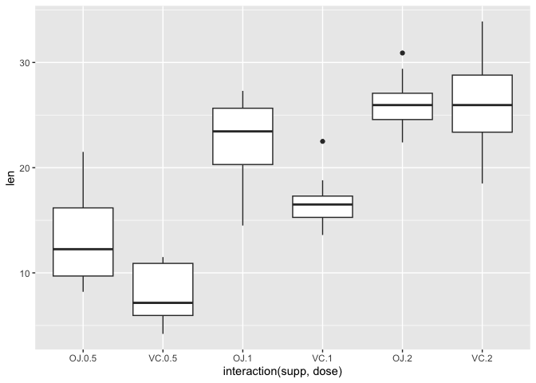

```r
ggplot(data = ToothGrowth,
       aes(x = interaction(supp, dose), y = len)) +
  geom_boxplot()
```

> Note 您可能已经注意到，来自`base R`中的`boxplot`与来自`ggplot2`的`boxplot`略有不同。这是因为它们计算分位数的方法略有不同。 `?geom_boxplot`和`?boxplot` 通过统计数据了解更多关于它们之间差异的信息。

可以在`Recipe 6.6`中学习更多的箱形图。

## 2.6 Plotting a Function Curve

### 2.6.1 Problem

绘制一个函数曲线

### 2.6.2 Solution

要绘制函数曲线`Function Curve`，使用`curve()`并且传递一个带有变量的`x`的表达式：

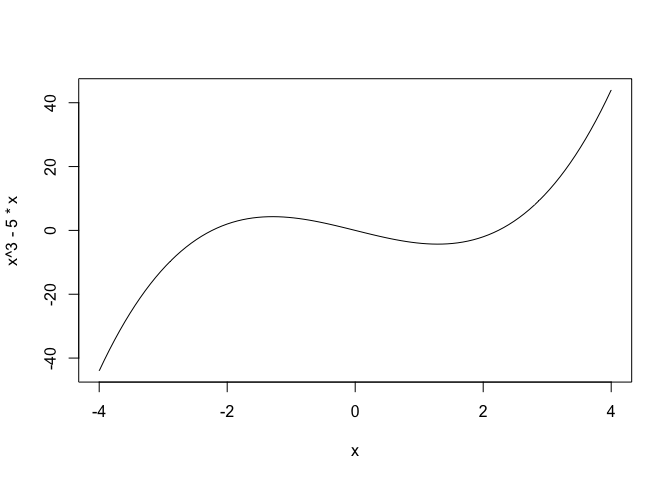

```r
curve(x^3 - 5*x, from = -4, to = 4)
```

您可以绘制任何接受数字向量作为输入并且返回数字向量的函数，包括你自己定义的函数。使用`add = TRUE`将在之前创建的图形中添加一条曲线：

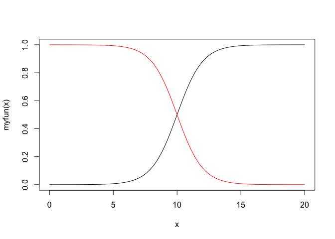

```r
# Plot a user-defined function

myfun <- function(xvar){
  1/(1 + exp(-xvar + 10))
}

curve(myfun(x), from = 0, to = 20)

# Add a line:
curve(1 - myfun(x), add = TRUE, col = "red")
```

对于`ggplot2`， 你可以通过`stat_function(geom = "line")` 并传递给它一个以数字向量作为输入并且返回数字向量的函数，可以得到一个类似的结果。

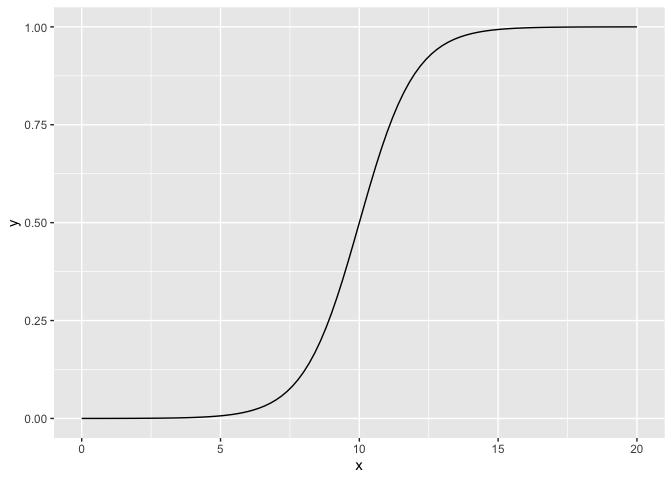

```r
library(ggplot2)

ggplot(data = data.frame(x = c(0, 20)), aes(x = x)) +
  stat_function(fun = myfun, geom = "line")
```

你可以在`Recipe 13.2`中深入学习绘制`function curves`。